# Mini Project 2: Data Wrangling

Ha Cao and Cathy Lee

March 20, 2018

### Load the data

```r
library(tidyverse)
library(RColorBrewer)
load("house_elections.rda")
load("candidates.rda")
load("committees.rda")
load("contributions.rda")
```

Please visit our Github repo for more details on our project [^1].

### Wrangle the data

Using data from the `contributions`, `candidates`, and `house_elections` tables, we investigated the relationship between the amount of donations, and subsequently number of votes, each candidate received in the house elections in 2012. Our hypothesis was that the greater the donation given, the greater the number votes received by each candidate would be, since the money could be used for public relations purposes to win public favour and garner votes for the candidate. We decided to extend our objective by also taking into account the candidates’ political affiliations, and how the parties performed in the house elections in general.

To wrangle the data needed to test this hypothesis, we joined the `contributions` and `candidates` tables by `cand_id`, since the candidate ID was the common factor in retrieving the amount of donations received by each candidate (from `contributions`) and the candidates’ political affiliations (from `candidates`). We filtered the data to only show results from 2012 (since `house_elections` only contains data from 2012), and to only contain donations advocating the candidate (since donations opposing the candidate would only harm their campaign).

```r
# join the contributions and candidates tables by cand_id
contributions_2012 <- contributions %>%
  inner_join(candidates, by = "cand_id") %>%
  filter(cand_election_yr == 2012) %>% # filter only elections in 2012
  filter(transaction_type == "24E") %>% # filter only advocating donations
  select(cand_party_affiliation, cand_id, transaction_amt, other_id) %>%
  group_by(cand_id) %>%
  summarize(N = n(),
            total_amt_per_can = sum(transaction_amt))
```

We joined the new table, `contributions_2012`, with `house_elections`, again by the candidate ID (aka FEC ID in `house_elections` table), since it is the common factor between all tables.

```r
# join contributions_2012 and house_elections tables by fec_id = cand_id
contributions_2012 <- contributions_2012 %>%
  inner_join(house_elections, by = c("cand_id" = "fec_id"))
```

We proceeded to calculate the percentage of votes (general, primary, and runoff) each candidate received out of the total number of votes in each category.

```r
# calculate the total number of votes for each kind of votes
total_ge <- sum(contributions_2012$general_votes)
total_primary <- sum(contributions_2012$primary_votes)
total_runoff <- sum(contributions_2012$runoff_votes)
# calculate the percentage of votes each candidate has
contributions_2012_vote_percent <- contributions_2012 %>%
  mutate(ge_percent = general_votes/total_ge,
         primary_percent = primary_votes/total_primary,
         runoff_percent = runoff_votes/total_runoff)
```

### Data graphics showing the relationship between amount of donations and votes received

With this data, we were able to examine the relationship between the amount of advocating donation received and the resulting percentage of votes by writing a function to plot a data graphic for each vote category.

```r
# write a function to draw a graph for a given y variable (specifically different kinds of votes),
# with x variable as total amount of advocating donations received by each candidate
draw_vote_graph <- function(y_var, color, graph_title){
  contributions_2012_vote_percent %>% ggplot(aes(x = total_amt_per_can)) +
    geom_line(aes(y = y_var), col = color) +
    labs(title = graph_title) +
    theme(axis.text.x = element_text(face = "bold", size = 12),
          axis.text.y = element_text(face = "bold", size = 12),
          axis.title.x = element_text(face = "bold", size = 13),
          axis.title.y = element_text(face = "bold", size = 13),
          plot.title = element_text(face = "bold", size = 13)) +
    scale_x_continuous(name = "Amount of advocating money received per candidate ($)", labels = scales::comma) +
    scale_y_continuous(name = "Percentage of votes per candidate", labels = scales::percent)
}
```

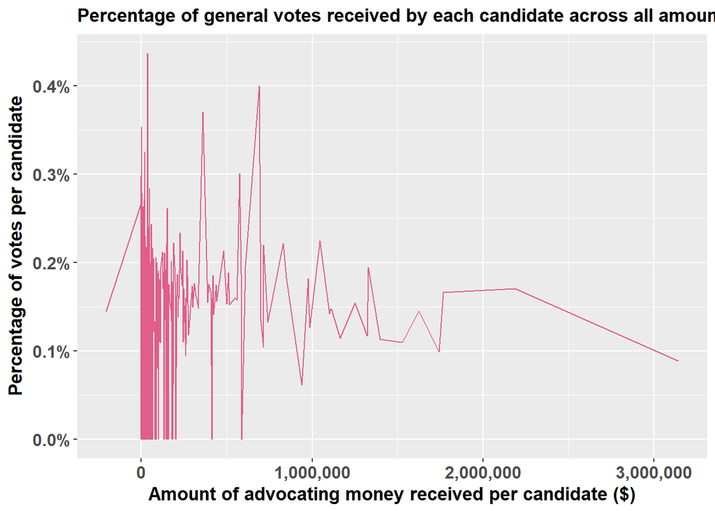

```r
# call function to draw graphs for each kind of votes
draw_vote_graph(contributions_2012_vote_percent$ge_percent, rgb(224/255, 94/255, 135/255), "Percentage of general votes received by each candidate across all amounts of advocating donations")
```

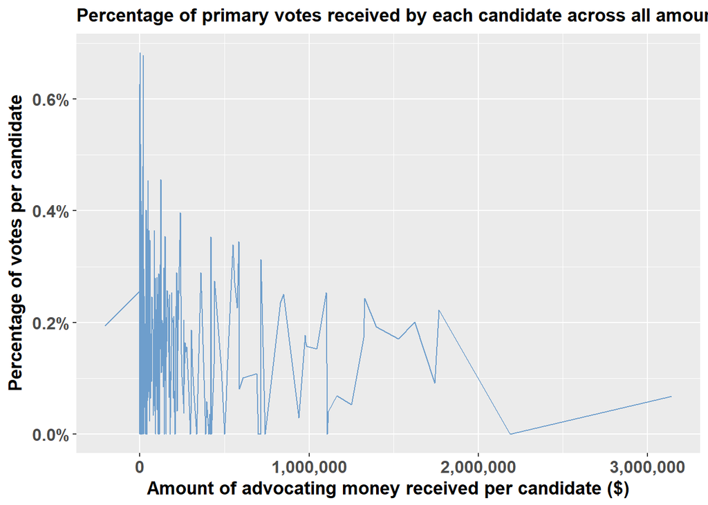

```r
draw_vote_graph(contributions_2012_vote_percent$primary_percent, rgb(110/255, 158/255, 204/255), "Percentage of primary votes received by each candidate across all amounts of advocating donations")
```

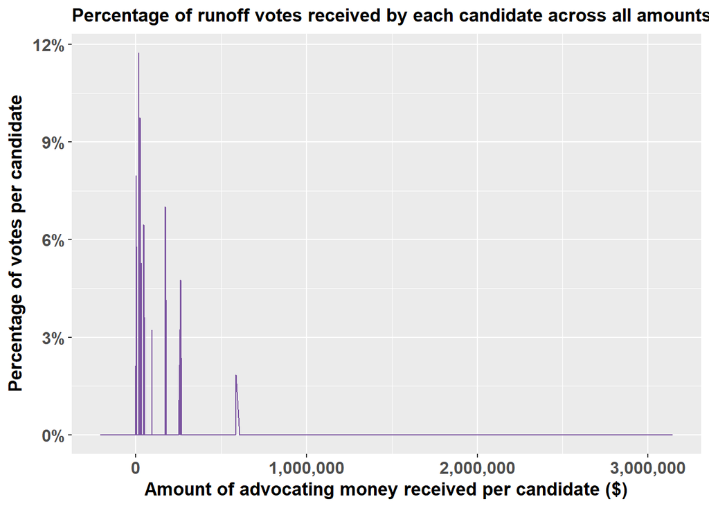

```r
draw_vote_graph(contributions_2012_vote_percent$runoff_percent, rgb(123/255, 83/255, 160/255), "Percentage of runoff votes received by each candidate across all amounts of advocating donations")
```

**Surprisingly**, all 3 graphs show a general downward trend. The more money candidates received, the fewer votes they received, in all kinds of votes, across all parties, contrary to popular belief. Despite the general downward trend, there are large fluctuations in the data, indicating that the relationship between donation amounts and votes received varies significantly. Upon further research, we discovered that many candidates tended to invest the most money in the closest races, while sacrificing the races that they knew they were going to lose. This explanation could account for the low percentages of votes garnered despite large amounts of money spent, and the sharp fluctuations in vote percentages at smaller amounts of money spent - candidates could have given up on the race entirely if they knew they were going to lose, and hence not earn many votes. On the other hand, if the race was a certain win for them, they would not have to spend any money to gain a high percentage of votes.

Next, we wanted to find out how many votes each party got, how much money it received, and how many wins it had in total as well to compare them against each other and see if the three bar graphs show similar patterns.

```r
# because one candidate can receive multiple donations
# but only has one number of votes
# so we group by cand_id to find the total amount of money one candidate received
contributions_2012_per_party <- contributions_2012 %>%
  group_by(party) %>%
  summarize(num_can = n(),
            total_amt = sum(total_amt_per_can),
            total_votes = sum(general_votes),
            num_win = sum(ifelse(ge_winner == "W", 1, 0))) %>%
  arrange(desc(total_votes))
```

### Data graphics showing the total amount of advocating donations and number of votes each party received in house elections in 2012

```r
draw_total <- function(y_variable, color, y_title, graph_title){
  contributions_2012_per_party %>%
  ggplot(aes(x = reorder(party, -y_variable))) +
  geom_bar(aes(y = y_variable), stat = "identity", fill = color) +
  labs(title = graph_title) +
  theme(axis.text.x = element_text(face = "bold", size = 12, angle = 45),
        axis.text.y = element_text(face = "bold", size = 12),
        axis.title.x = element_text(face = "bold", size = 13),
        axis.title.y = element_text(face = "bold", size = 13),
        plot.title = element_text(face = "bold", size = 15)) +
  scale_x_discrete(name = "Party", labels = c("R" = "Republican", "D" = "Democratic", "U" = "Unknown", "L" = "Libertarian", "I" = "Independent", "N" = "Nullifer", "W" = "Whig")) +
  scale_y_continuous(name = y_title, labels = scales::comma)
}
```

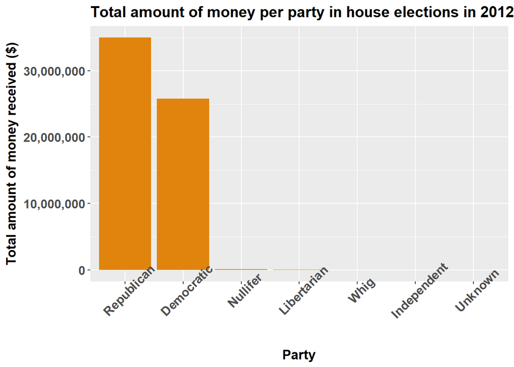

```r
# call function to draw graphs for total amount of money and total number of votes
draw_total(contributions_2012_per_party$total_amt, rgb(224/255, 132/255, 13/255), "Total amount of money received ($)", "Total amount of money per party in house elections in 2012")
```

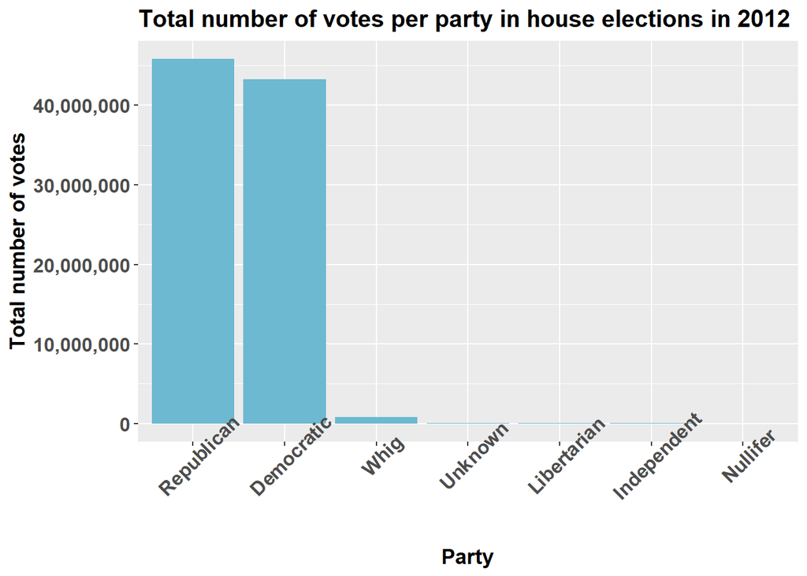

```r
draw_total(contributions_2012_per_party$total_votes, rgb(108/255, 185/255, 209/255), "Total number of votes", "Total number of votes per party in house elections in 2012")
```

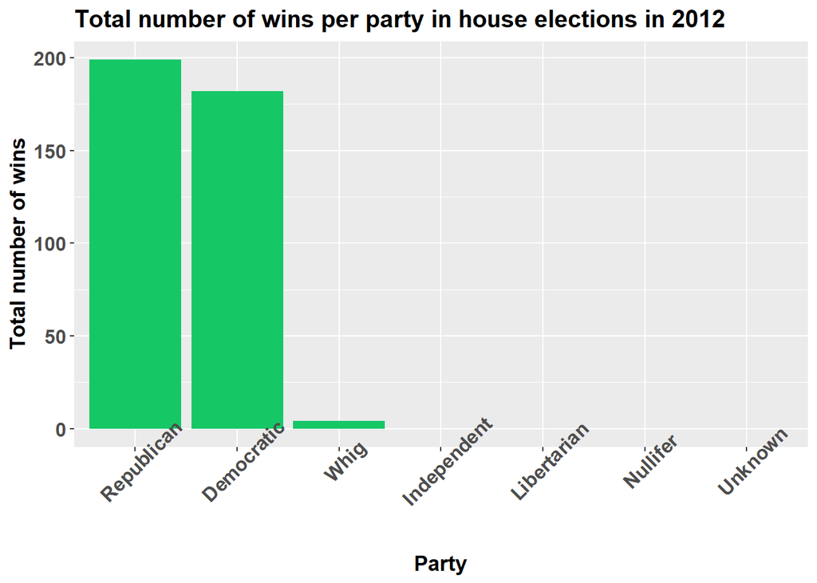

```r
draw_total(contributions_2012_per_party$num_win, rgb(22/255, 199/255, 102/255), "Total number of wins", "Total number of wins per party in house elections in 2012")
```

We drew bar graphs for each political party. We can see that Republican and Democratic are the two parties that account for most votes, most money, and most wins. Republicans outdid Democrats in all three aspects in house elections in 2012. Looking more closely, however, we see that Republicans received significantly more donations than Democrats, but only slightly more votes, indicating that more money invested does not necessarily lead to more votes.

From the data, we can infer that spending money during an election does not always translate to a win for the candidate; in fact, the general downward trend in the first set of graphs indicates that candidates who spend more money tend to garner less votes.

### References

Bump, Philip. “Does More Campaign Money Actually Buy More Votes: An Investigation.” *The Atlantic*, Atlantic Media Company, November 11, 2013. Retrieved from: https://www.theatlantic.com/politics/archive/2013/11/does-more-campaign-money-actually-buy-more-votes-investigation/355154/ on March 22, 2018.

[^1]: https://github.com/cathyleee/sds192-mp2